# Homework 6

Olivia Quinn

5/23/2022

### Loading Packages

```r
#install.packages("rpart.plot")
library(rpart.plot)
#install.packages("vip")
library(vip)
#install.packages("randomForest")
library(randomForest)
#install.packages("xgboost")
library(xgboost)
#install.packages("ranger")
library(ranger)

library(tidyverse)
library(tidymodels)
library(ISLR)
library(janitor)
library(corrplot)
```

## Tree-Based Models

The goal of this assignment is to build a statistical learning model that can predict the **primary type** of a Pokémon based on its generation, legendary status, and six battle statistics.

### Exercise 1

Read in the data, use `clean_names()`, filter out the rarer Pokémon types, convert `type_1` and `legendary` to factors:

```r
pokemon <- read_csv("data/Pokemon.csv")
pokemon <- clean_names(pokemon)

dat <- pokemon %>%
  filter(type_1 %in% c("Bug", "Fire", "Grass", "Normal", "Water", "Psychic"))

dat <- dat %>%
  mutate(type_1 = as.factor(type_1)) %>%
  mutate(legendary = as.factor(legendary)) %>%
  mutate(generation = as.factor(generation))
```

Initial split + stratify on the outcome variable:

```r
set.seed(24)
poke_split <- initial_split(dat, prop = 0.70, strata = type_1)
poke_train <- training(poke_split)
poke_test <- testing(poke_split)

dim(poke_train)
```

```
## [1] 318  13
```

```r
dim(poke_test)
```

```
## [1] 140  13
```

Fold the training set using *v*-fold cross-validation + stratify on the outcome variable:

```r
poke_folds <- vfold_cv(poke_train, v = 5, strata = type_1)
poke_folds
```

```
## #  5-fold cross-validation using stratification
## # A tibble: 5 × 2
##   splits           id
##   <list>           <chr>
## 1 <split [252/66]> Fold1
## 2 <split [253/65]> Fold2
## 3 <split [253/65]> Fold3
## 4 <split [256/62]> Fold4
## 5 <split [258/60]> Fold5
```

Recipe to predict `type_1` with `legendary`, `generation`, `sp_atk`, `attack`, `speed`, `defense`, `hp`, and `sp_def` (dummy the factors + center and scale all predictors):

```r
poke_recipe <- recipe(type_1 ~ legendary + generation + sp_atk + attack + speed + defense + hp + sp_def, data = poke_train) %>%
  step_dummy(legendary) %>%
  step_dummy(generation) %>%
  step_normalize(all_predictors())
```

### Exercise 2

Correlation matrix:

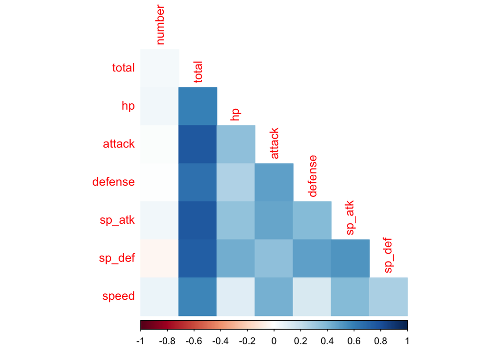

```r
poke_train %>%
  select(is.numeric) %>%
  cor() %>%
  corrplot(type = 'lower', diag = FALSE,
           method = 'color')
```

I chose to only include the numeric variables in this correlation matrix because the name and type variables are factors without an inherent ordering. They cannot be converted to a nominal or ordinal scale.

There are positive relationships between most pokemon stats: i.e. between pokemon hit points, attack, defense, special attack, special defense, and speed. It makes sense that pokemon with greater attack stats would also be better defenders!

### Exercise 3

Decision tree model and workflow + tune ‘cost_complexity’ with `range = c(-3, -1)` + optimize ‘roc_auc’:

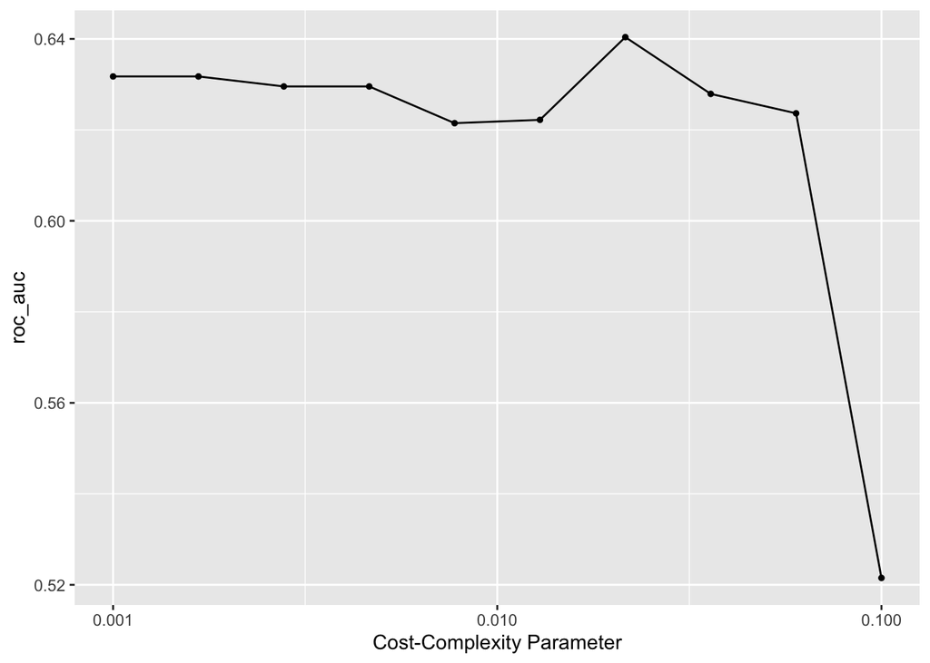

```r
tree_spec <- decision_tree() %>%
  set_engine("rpart")

class_tree_spec <- tree_spec %>%
  set_mode("classification")

class_tree_wf <- workflow() %>%
  add_model(class_tree_spec %>% set_args(cost_complexity = tune())) %>%
  add_recipe(poke_recipe)

param_grid <- grid_regular(cost_complexity(range = c(-3, -1)), levels = 10)

tune_res <- tune_grid(
  class_tree_wf,
  resamples = poke_folds,
  grid = param_grid,
  metrics = metric_set(roc_auc)
)

autoplot(tune_res)
```

A single decision tree performs best with a small/medium sized complexity penalty, with a peak around ~0.02.

### Exercise 4

The ROC_AUC of the best-performing pruned tree (on the folds) is 0.64.

```r
tune_res %>%
  collect_metrics() %>%
  arrange(-mean)
```

```
## # A tibble: 10 × 7
##    cost_complexity .metric .estimator  mean     n std_err .config
##              <dbl> <chr>   <chr>      <dbl> <int>   <dbl> <chr>
##  1         0.0215  roc_auc hand_till  0.640     5 0.0162  Preprocessor1_Model07
##  2         0.001   roc_auc hand_till  0.632     5 0.0276  Preprocessor1_Model01
##  3         0.00167 roc_auc hand_till  0.632     5 0.0276  Preprocessor1_Model02
##  4         0.00278 roc_auc hand_till  0.630     5 0.0267  Preprocessor1_Model03
##  5         0.00464 roc_auc hand_till  0.630     5 0.0267  Preprocessor1_Model04
##  6         0.0359  roc_auc hand_till  0.628     5 0.0120  Preprocessor1_Model08
##  7         0.0599  roc_auc hand_till  0.624     5 0.00784 Preprocessor1_Model09
##  8         0.0129  roc_auc hand_till  0.622     5 0.0213  Preprocessor1_Model06
##  9         0.00774 roc_auc hand_till  0.621     5 0.0278  Preprocessor1_Model05
## 10         0.1     roc_auc hand_till  0.522     5 0.0215  Preprocessor1_Model10
```

### Exercise 5

Fitting and visualizing the best-performing pruned decision tree with training data:

Fit:

```r
best_complexity <- select_best(tune_res)

class_tree_final <- finalize_workflow(class_tree_wf, best_complexity)

class_tree_final_fit <- fit(class_tree_final, data = poke_train)
```

Visualize:

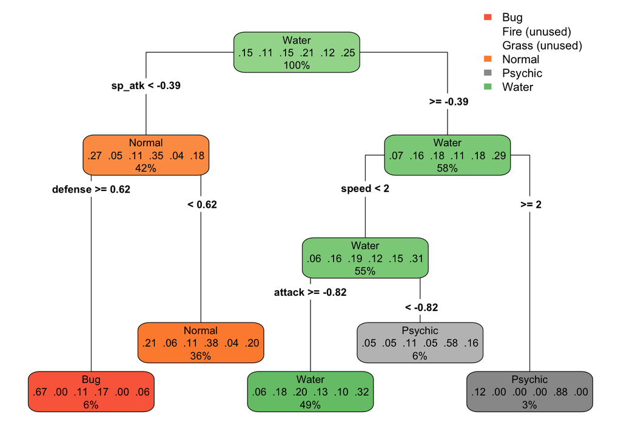

```r
class_tree_final_fit %>%
  extract_fit_engine() %>%
  rpart.plot(type = 4)
```

### Exercise 5

Fandom forest model and workflow + `ranger` engine and `importance = "impurity"` + tune `mtry`, `trees`, and `min_n`:

- ‘mtry’ refers to the number of predictors which each tree will be trained on.
- ‘trees’ refers to the total number of trees to be fit.
- ‘min_n’ refers to the minimum number of observations in a node that are required for the node to be split further.

For the regular grid, a model with ‘mtry = 8’ would represent a tree trained on all 8 predictors, which would be a bagging model.

```r
rf_spec <- rand_forest() %>%
  set_engine("ranger", importance = "impurity") %>%
  set_mode("classification")

rf_wf <- workflow() %>%
  add_model(rf_spec %>% set_args(mtry = tune(), trees = tune(), min_n = tune())) %>%
  add_recipe(poke_recipe)

rf_grid <- grid_regular(mtry(range = c(1, 8)),
                        trees(range = c(100,1000)),
                              min_n(range = c(2,10)),
                                levels = 8)
```

### Exercise 6

Tuned model with ‘roc_auc’ metric:

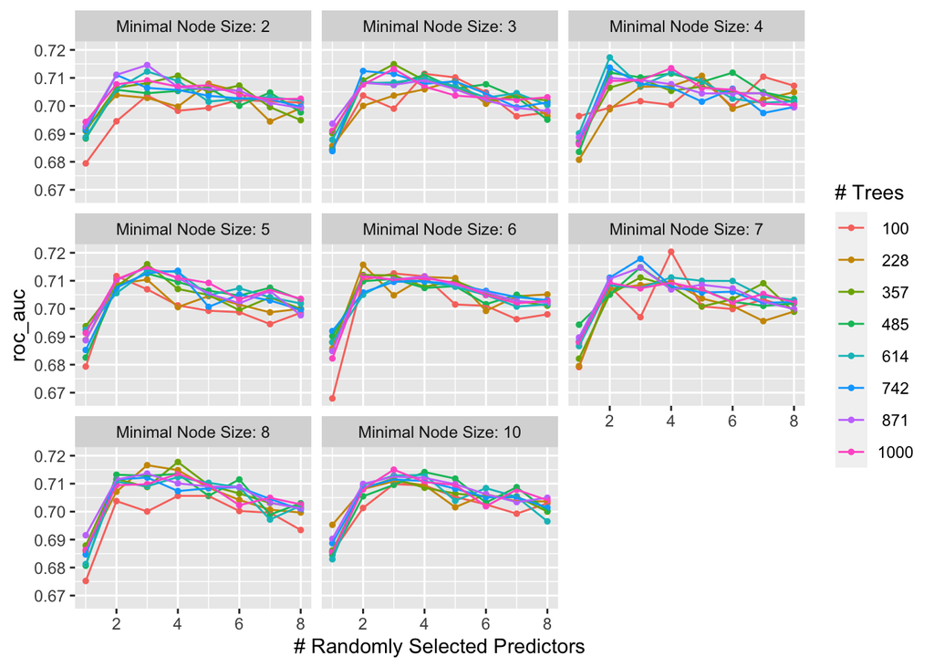

```r
# saved and loaded because took 15 minutes to run!

#rf_tune_res <- tune_grid(
#  rf_wf,
#  resamples = poke_folds,
#  grid = rf_grid,
#  metrics = metric_set(roc_auc))

#saveRDS(rf_tune_res, file = "rf_tune_res.rds")

rf_tune_res <- readRDS(file = "rf_tune_res.rds")

autoplot(rf_tune_res)
```

The tuning results show that the best performance is gained by using at least two predictors, at least 100 trees, and larger minimal node sizes. Different ranges for each of these hyperparameters might yield better performances, but I will keep them as is. Roc_auc appears to level off around ~0.70, however, so tuning more may not be more helpful.

### Exercise 7

The ROC_AUC of the best-performing random forest model is 0.72.

```r
rf_tune_res %>%
  collect_metrics() %>%
  arrange(-mean)
```

```
## # A tibble: 512 × 9
##     mtry trees min_n .metric .estimator  mean     n std_err .config
##    <int> <int> <int> <chr>   <chr>      <dbl> <int>   <dbl> <chr>
##  1     4   100     7 roc_auc hand_till  0.720     5 0.00568 Preprocessor1_Model…
##  2     3   742     7 roc_auc hand_till  0.718     5 0.00567 Preprocessor1_Model…
##  3     4   357     8 roc_auc hand_till  0.718     5 0.00695 Preprocessor1_Model…
##  4     2   614     4 roc_auc hand_till  0.717     5 0.00627 Preprocessor1_Model…
##  5     3   228     8 roc_auc hand_till  0.717     5 0.00490 Preprocessor1_Model…
##  6     3   357     5 roc_auc hand_till  0.716     5 0.00500 Preprocessor1_Model…
##  7     2   228     6 roc_auc hand_till  0.716     5 0.00785 Preprocessor1_Model…
##  8     3  1000    10 roc_auc hand_till  0.715     5 0.00434 Preprocessor1_Model…
##  9     3   357     3 roc_auc hand_till  0.715     5 0.00530 Preprocessor1_Model…
## 10     3  1000     5 roc_auc hand_till  0.715     5 0.00420 Preprocessor1_Model…
## # … with 502 more rows
```

### Exercise 8

Variable importance plot with best-performing random forest model and training:

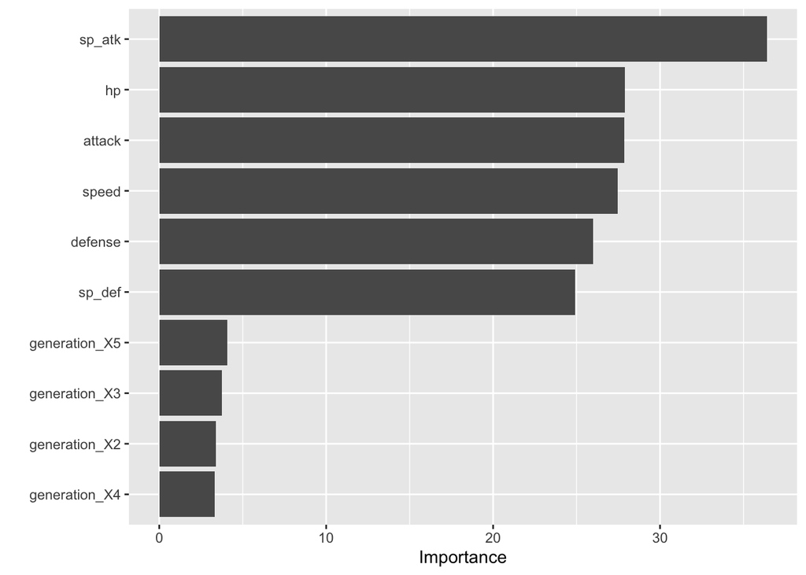

```r
best_rf_tune <- select_best(rf_tune_res, metric = "roc_auc")

rf_final <- finalize_workflow(rf_wf, best_rf_tune)

rf_final_fit <- fit(rf_final, data = poke_train)

rf_final_fit%>%
  pull_workflow_fit()%>%
  vip()
```

The attack/defense variables are most useful, which is what I expected given the correlation matrix and my priors about pokemon. Special attack looks like it is the most useful predictor. The generation of pokemon seems to not be very useful at all in predicting primary type.

### Exercise 9

Boosted tree model and workflow (`xgboost` engine) + tune `trees`:

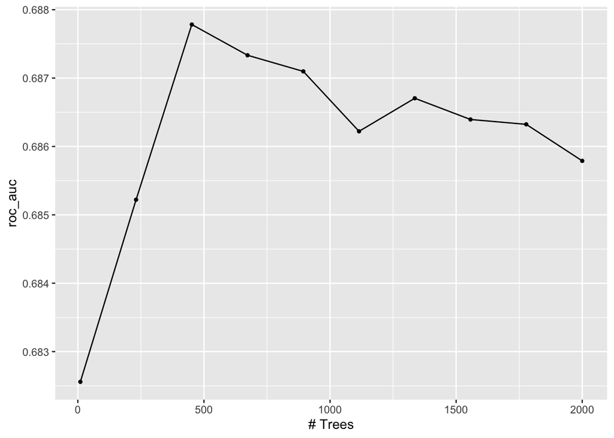

```r
boost_spec <- boost_tree() %>%
  set_engine("xgboost") %>%
  set_mode("classification")

boost_wf <- workflow() %>%
  add_model(boost_spec %>% set_args(trees = tune())) %>%
  add_recipe(poke_recipe)

boost_grid <- grid_regular(trees(range = c(10,2000)),levels = 10)

boost_tune_res <- tune_grid(
  boost_wf,
  resamples = poke_folds,
  grid = boost_grid,
  metrics = metric_set(roc_auc))

autoplot(boost_tune_res)
```

Accuracy peaks at about 500 trees, but decreases with more. The ROC_AUC of the best-performing boosted tree model is 0.688.

```r
boost_tune_res %>%
  collect_metrics() %>%
  arrange(-mean)
```

```
## # A tibble: 10 × 7
##    trees .metric .estimator  mean     n std_err .config
##    <int> <chr>   <chr>      <dbl> <int>   <dbl> <chr>
##  1   452 roc_auc hand_till  0.688     5 0.0111  Preprocessor1_Model03
##  2   673 roc_auc hand_till  0.687     5 0.0117  Preprocessor1_Model04
##  3   894 roc_auc hand_till  0.687     5 0.0120  Preprocessor1_Model05
##  4  1336 roc_auc hand_till  0.687     5 0.0122  Preprocessor1_Model07
##  5  1557 roc_auc hand_till  0.686     5 0.0125  Preprocessor1_Model08
##  6  1778 roc_auc hand_till  0.686     5 0.0125  Preprocessor1_Model09
##  7  1115 roc_auc hand_till  0.686     5 0.0120  Preprocessor1_Model06
##  8  2000 roc_auc hand_till  0.686     5 0.0126  Preprocessor1_Model10
##  9   231 roc_auc hand_till  0.685     5 0.00914 Preprocessor1_Model02
## 10    10 roc_auc hand_till  0.683     5 0.00983 Preprocessor1_Model01
```

### Exercise 10

Compare ROC AUC values for best-performing pruned tree, random forest, and boosted tree models:

```r
#need to combine all three res models by roc_auc... which select_best doesn't pull out for some reason
tune_res_compare <-  show_best(tune_res, metric = "roc_auc", n = 1)
rf_compare <- show_best(rf_tune_res, metric = "roc_auc", n = 1)
boost_compare <- show_best(boost_tune_res, metric = "roc_auc", n = 1)

AUCs <- c(tune_res_compare$mean, rf_compare$mean,
                boost_compare$mean)
models <- c("Pruned", "RF", "Boosted")
results <- tibble(AUCs = AUCs, models = models)
results %>%
  arrange(-AUCs)
```

```
## # A tibble: 3 × 2
##    AUCs models
##   <dbl> <chr>
## 1 0.720 RF
## 2 0.688 Boosted
## 3 0.640 Pruned
```

Fit to RF model to the testing set:

```r
augment(rf_final_fit, new_data = poke_test) %>%
  roc_auc(type_1, estimate = c(.pred_Bug, .pred_Fire, .pred_Grass, .pred_Normal, .pred_Psychic, .pred_Water))
```

```
## # A tibble: 1 × 3
##   .metric .estimator .estimate
##   <chr>   <chr>          <dbl>
## 1 roc_auc hand_till      0.699
```

ROC curve:

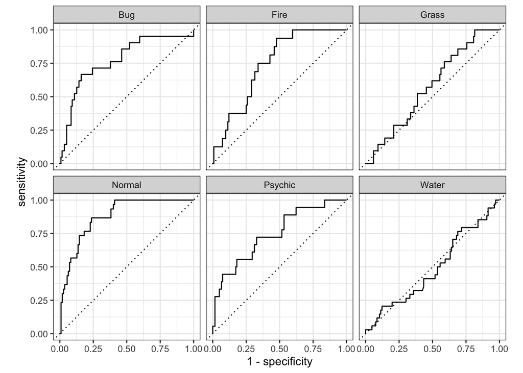

```r
augment(rf_final_fit, new_data = poke_test) %>%
  roc_curve(type_1, estimate = c(.pred_Bug, .pred_Fire, .pred_Grass, .pred_Normal, .pred_Psychic, .pred_Water)) %>%
  autoplot()
```

Heatmap:

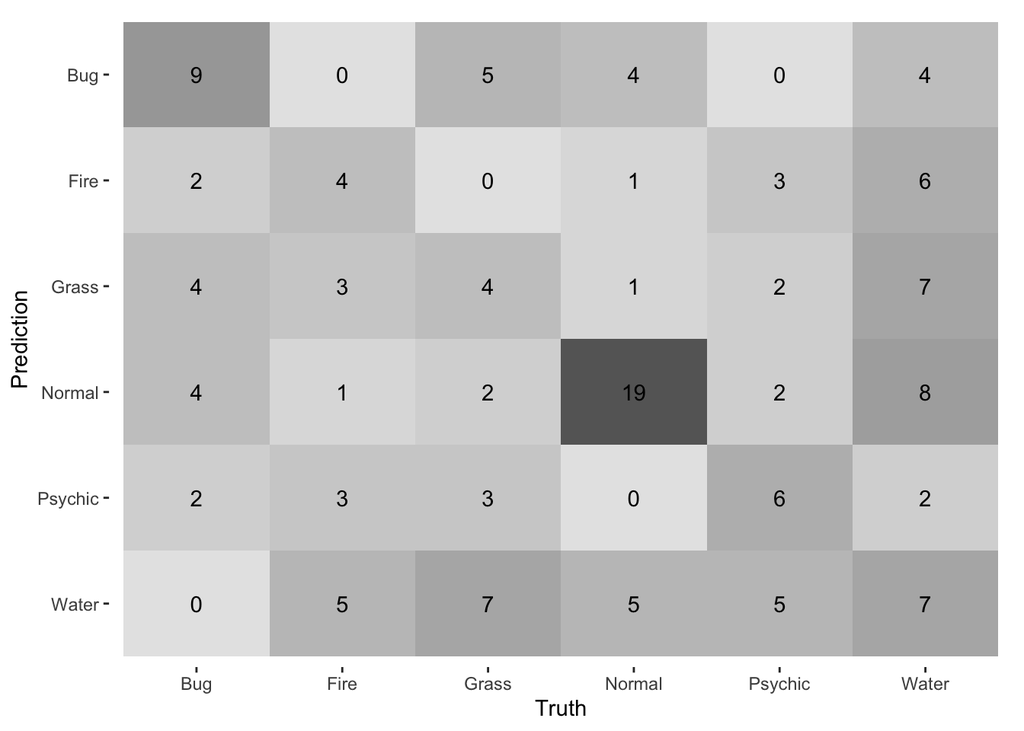

```r
augment(rf_final_fit, new_data = poke_test) %>%
  conf_mat(truth = type_1, estimate = .pred_class) %>%
  autoplot(type = "heatmap")
```

The random forest model is best at predicting the Normal and Bug type Pokemon, and is worst at predicting the Water and Grass types.

## For 231 Students

### Exercise 11

Random forest model predicting abalone ‘age’ + tune `mtry`, `min_n`, and `trees`:

Dat & CV:

```r
abalone <- read_csv("data/abalone.csv")

abalone <- abalone %>%
  mutate(age = rings + 1.5)

set.seed(24)

abalone_split <- initial_split(abalone, prop = 0.80,
                                strata = age)
abalone_train <- training(abalone_split)
abalone_test <- testing(abalone_split)

abalone_folds <- vfold_cv(abalone_train, v = 5, strata = age)
```

RF model:

```r
#leave out rings
abalone_recipe <- recipe(age ~ type + longest_shell + diameter + height + whole_weight + shucked_weight + viscera_weight + shell_weight, data = abalone_train) %>%
  step_dummy(all_nominal_predictors()) %>%
  step_normalize(all_predictors())

abalone_rf_spec <- rand_forest() %>%
  set_engine("randomForest", importance = TRUE) %>%
  set_mode("regression")

abalone_rf_wf <- workflow() %>%
  add_model(abalone_rf_spec %>% set_args(mtry = tune(), trees = tune(), min_n = tune())) %>%
  add_recipe(abalone_recipe)

abalone_grid <- grid_regular(mtry(range = c(1, 8)),
                        trees(range = c(10,200)),
                              min_n(range = c(10,100)),
                                levels = 8)
```

Tune:

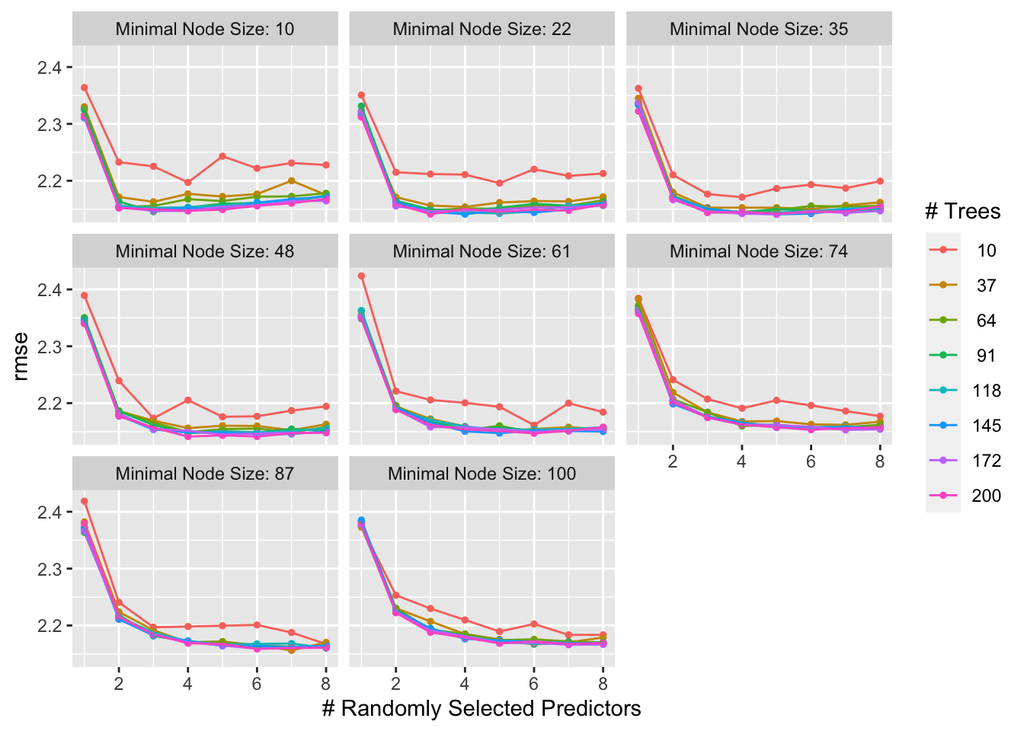

```r
#abalone_rf_tune_res <- tune_grid(
 # abalone_rf_wf,
 # resamples = abalone_folds,
 # grid = abalone_grid,
 # metrics = metric_set(rmse))

#saveRDS(abalone_rf_tune_res, file = "abalone_rf_tune_res.rds")

abalone_rf_tune_res <- readRDS(file = "abalone_rf_tune_res.rds")

autoplot(abalone_rf_tune_res)
```

Fit best on full training set:

```r
best_abalone_tune <- select_best(abalone_rf_tune_res, metric = "rmse")

abalone_rf_final <- finalize_workflow(abalone_rf_wf, best_abalone_tune)

abalone_rf_final_fit <- fit(abalone_rf_final, data = abalone_train)
```

Testing performance:

```r
augment(abalone_rf_final_fit, new_data = abalone_test) %>%
  rmse(truth = age, estimate = .pred)
```

```
## # A tibble: 1 × 3
##   .metric .estimator .estimate
##   <chr>   <chr>          <dbl>
## 1 rmse    standard        2.11
```

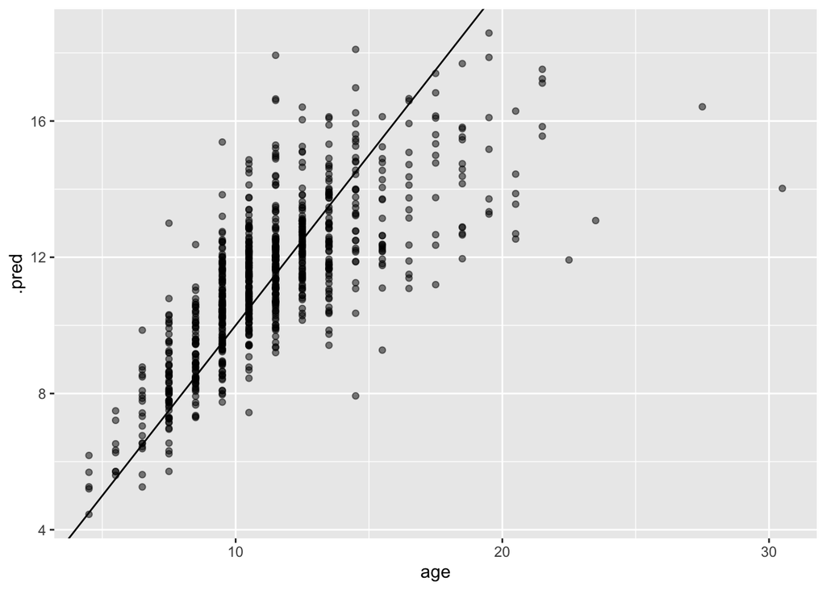

```r
augment(abalone_rf_final_fit, new_data = abalone_test) %>%
  ggplot(aes(age, .pred)) +
  geom_abline() +
  geom_point(alpha = 0.5)
```